# set4

#### 2.The data below represent the monthly sales (in thousands) of product A for a plastics manufacturer for years 1 through 5 (data set plastics)

```r
data(plastics)
plastics
```

```
##    Jan  Feb  Mar  Apr  May  Jun  Jul  Aug  Sep  Oct  Nov  Dec
## 1  742  697  776  898 1030 1107 1165 1216 1208 1131  971  783
## 2  741  700  774  932 1099 1223 1290 1349 1341 1296 1066  901
## 3  896  793  885 1055 1204 1326 1303 1436 1473 1453 1170 1023
## 4  951  861  938 1109 1274 1422 1486 1555 1604 1600 1403 1209
## 5 1030 1032 1126 1285 1468 1637 1611 1608 1528 1420 1119 1013
```

> 1. Plot the time series of sales of product A. Can you identify seasonal fluctuations and/or a trend?

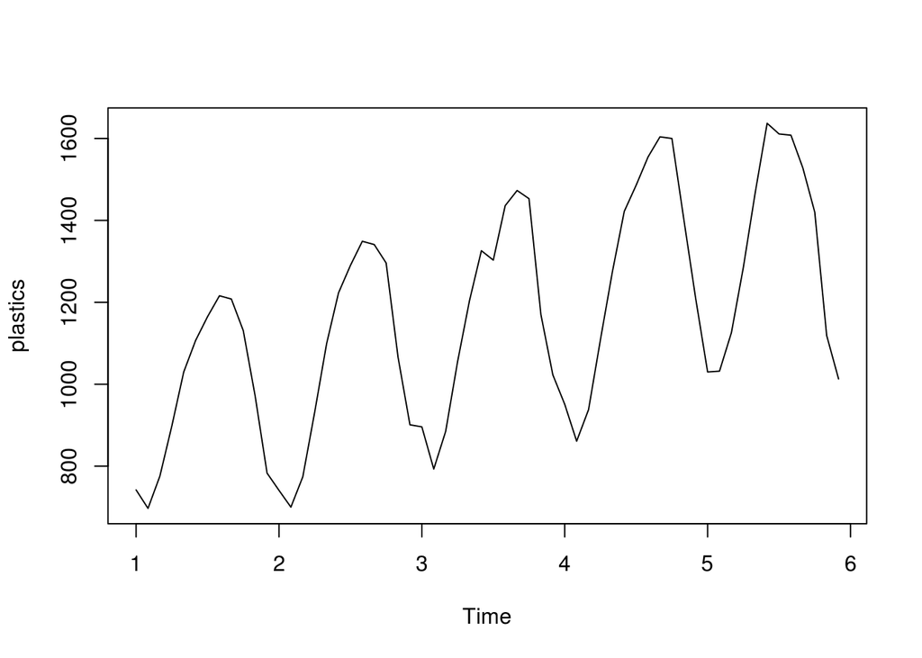

```r
plot(plastics)
```

Temos uma trend que está aumentando conforme os anos e uma sazonalidade anual.

> 2. Use an STL decomposition to calculate the trend-cycle and seasonal indices. (Experiment with having fixed or changing seasonality.)

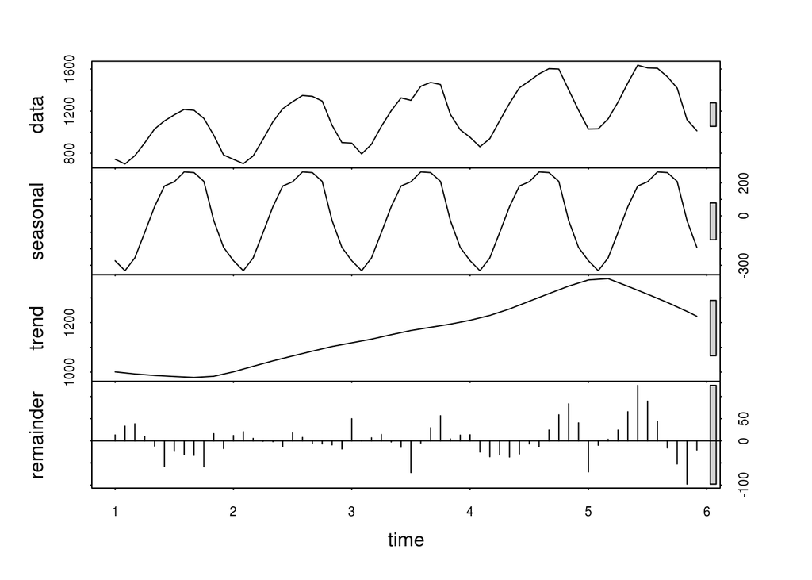

```r
plastics.fit <- stl(plastics, s.window="periodic")
plot(plastics.fit)
```

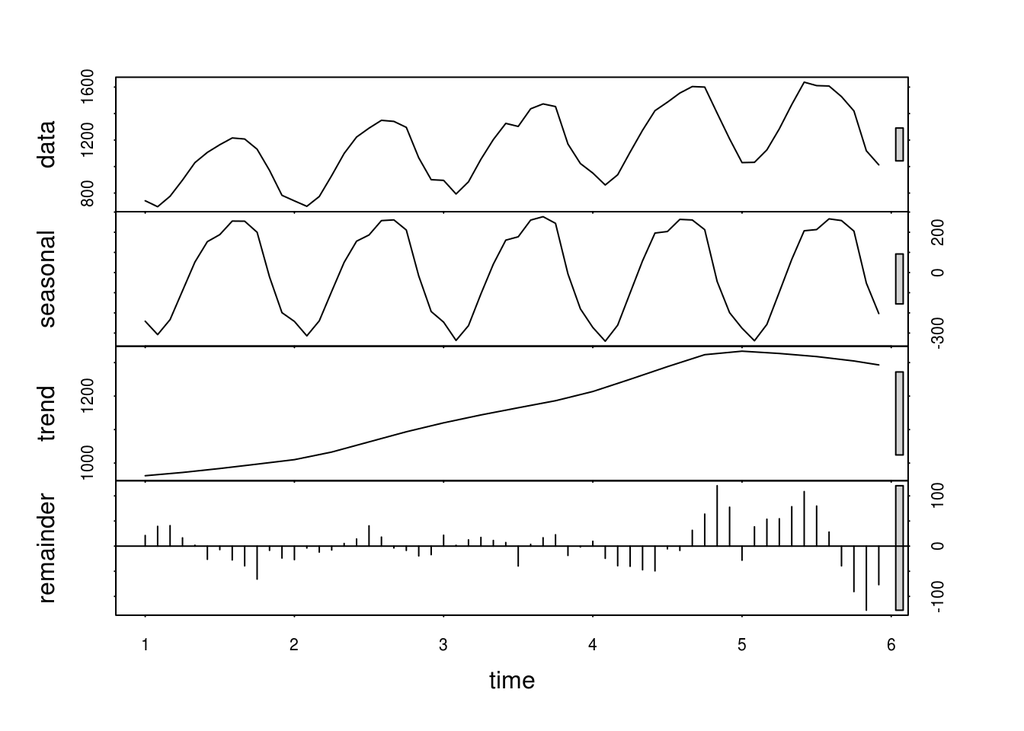

```r
plastics.fit <- stl(plastics, s.window=5)
plot(plastics.fit)
```

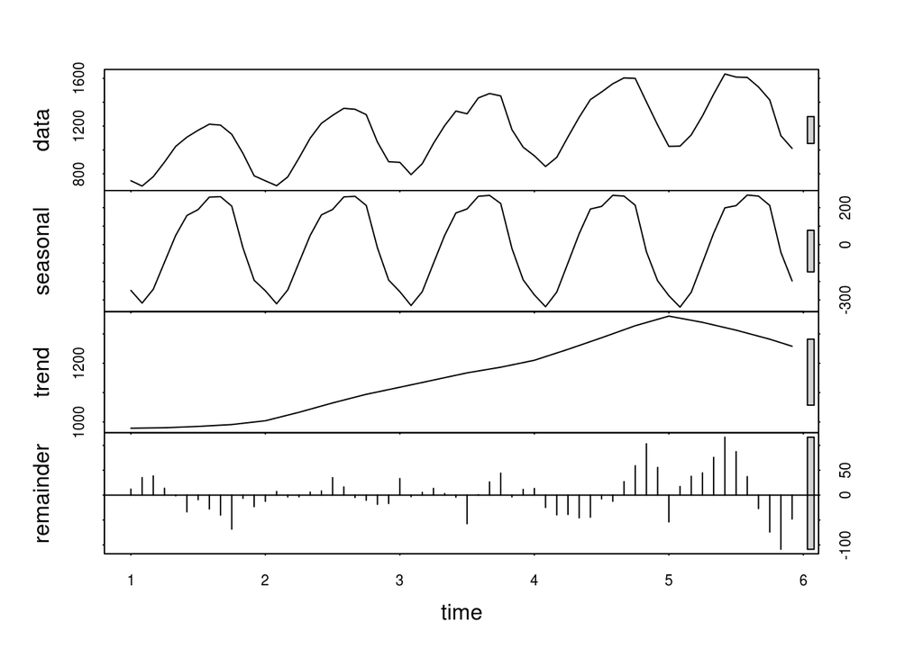

```r
plastics.fit <- stl(plastics, s.window=7)
plot(plastics.fit)
```

Restos e trend sofreram grandes alterações, mas qual o melhor?

> 3. Do the results support the graphical interpretation from part (a)?

Sim!

> 4. Compute and plot the seasonally adjusted data

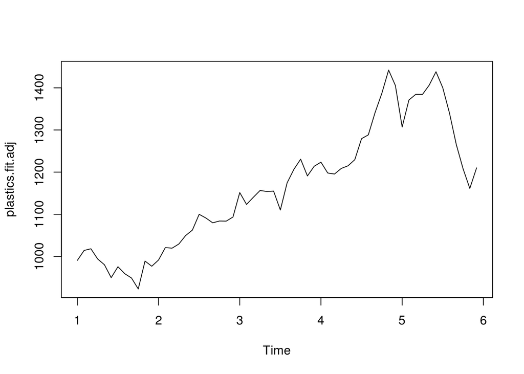

```r
plastics.fit.adj <- seasadj(plastics.fit)
plot(plastics.fit.adj)
```

> 5. Change one observation to be an outlier (e.g., add 500 to one observation), and recompute the seasonally adjusted data. What is the effect of the outlier

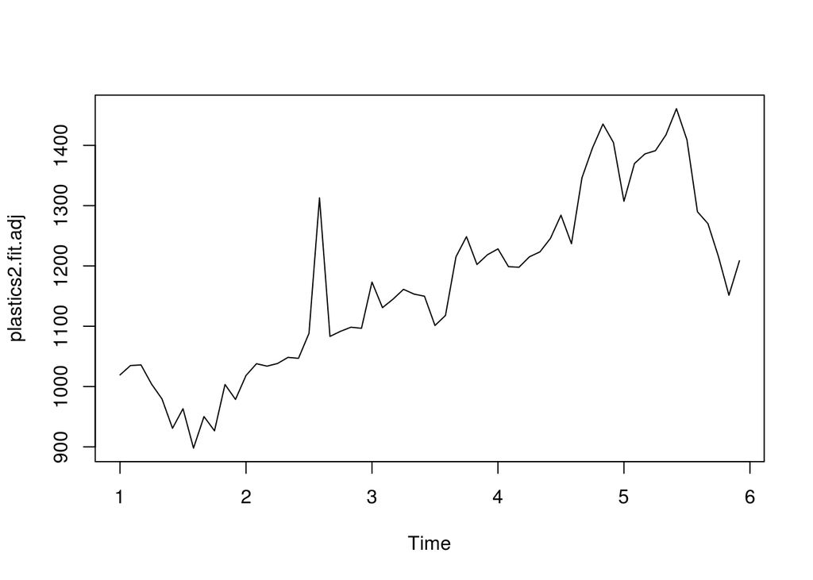

```r
plastics2 <- plastics
plastics2[20] <- plastics2[10] + 500
plastics2.fit <- stl(plastics2, s.window="periodic")
plastics2.fit.adj <- seasadj(plastics2.fit)
plot(plastics2.fit.adj)
```

> 6. Does the outlier have an effect if you use robust=TRUE with the stl function?

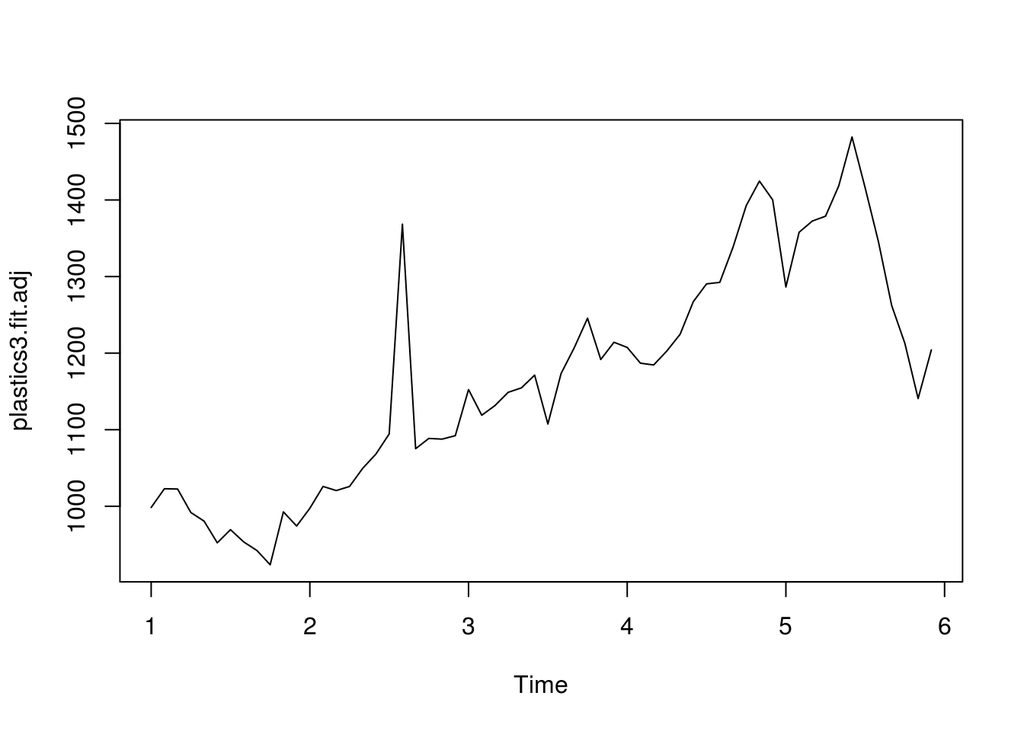

```r
plastics3 <- plastics
plastics3[20] <- plastics3[10] + 500
plastics3.fit <- stl(plastics3, s.window="periodic", robust=TRUE)
plastics3.fit.adj <- seasadj(plastics3.fit)
plot(plastics3.fit.adj)
```

> 7. Does it make any difference if the outlier is near the end rather than in the middle of the time series?

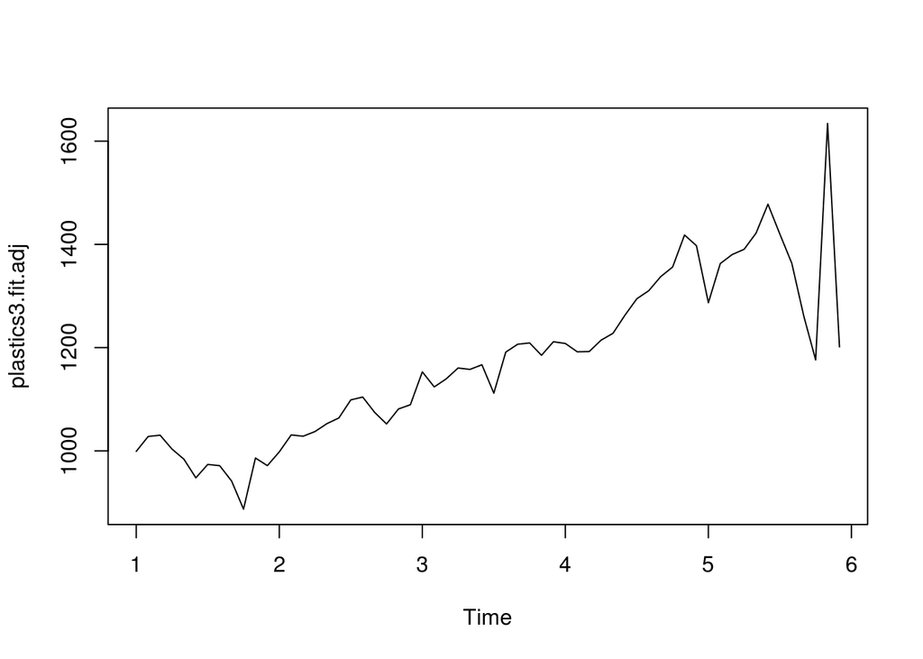

```r
plastics3 <- plastics
plastics3[59] <- plastics3[59] + 500
plastics3.fit <- stl(plastics3, s.window="periodic", robust=TRUE)
plastics3.fit.adj <- seasadj(plastics3.fit)
plot(plastics3.fit.adj)
```

> 8. Use a random walk to produce forecasts of the seasonally adjusted data.

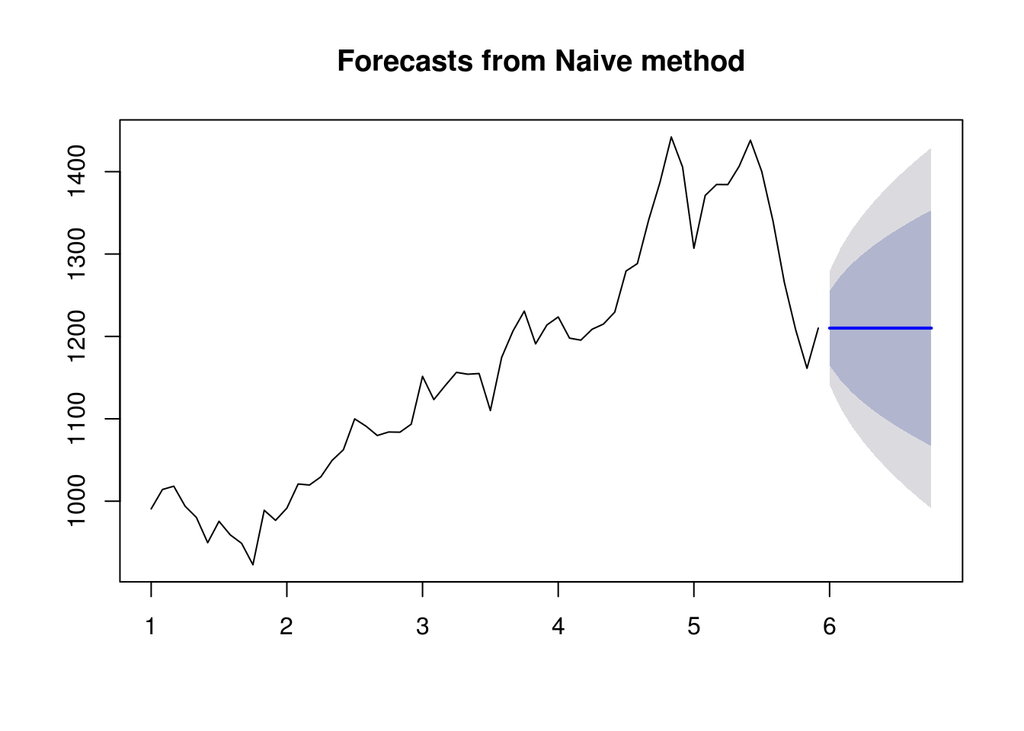

```r
plot(naive(plastics.fit.adj))
```

> 1. Reseasonalize the results to give forecasts on the original scale.

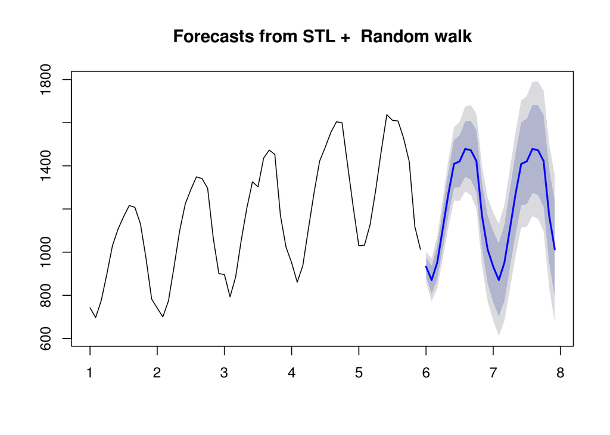

```r
plastics.fcast <- forecast(plastics.fit, method="naive")
plot(plastics.fcast)
```